# 20170624_Batch_44_CSE7212c_Python_Numpy_Pandas

```python
import time
start = time.time()
#returns time from Thursday, 1 January 1970 in seconds
```

## Modules

A module is a file containing Python definitions and statements. A module can contain functions , classes and variables.

```python
# # A simple module, calc.py

# def add(x, y):
#     return (x+y)

# def subtract(x, y):
#     return (x-y)
```

#### The import statement

When interpreter encounters an import statement, it imports the module if the module is present in the search path. A search path is a list of directories that the interpreter searches for importing a module.

To import the module calc.py, we need to put the following command at the top of the script :

```python
import calc
```

```python
calc.add(1,3)
```

```
4
```

```python
calc.subtract(3,4)
```

```
-1
```

#### The from import Statement

`from` statement lets you import specific attributes from a module.

```python
#  let us import add from calc module
```

```python
from calc import add
```

```python
add(1,3)
```

```
4
```

How will we know which functions are present in a module?

##### The dir() function

```python
dir(calc)
```

```
['__builtins__',
 '__cached__',
 '__doc__',
 '__file__',
 '__loader__',
 '__name__',
 '__package__',
 '__spec__',
 'add',
 'subtract']
```

## Numpy

Numpy is the core library for scientific computing in Python. It provides a high-performance multidimensional array object, and tools for working with these arrays.

To use Numpy, we first need to import the numpy package:

[figure not shown]

```python
from IPython.display import Image
Image(filename='numpy_image.jpg')
```

```python
import numpy as np
```

### Arrays

A numpy array is a grid of values, all of the *same* type, and is indexed by a tuple of nonnegative integers. The number of dimensions is the rank of the array; the shape of an array is a tuple of integers giving the size of the array along each dimension.

We can initialize numpy arrays from nested Python lists, and access elements using square brackets

###### Why should I use numpy arrays instead of lists you ask?

- Convinient
- Faster and have more functionality than lists
- Optimized storage and retrieval

Let me try to prove some of these claims

##### Creating A NumPy Array

```python
a = np.array([1, 2, 3])  # Create a rank 1 array
print (type(a))
print (a.shape)
print (a[0], a[1], a[2])
```

```
<class 'numpy.ndarray'>
(3,)
1 2 3
```

```python
l = [1,2,3,4,5]
a = np.array(l)
```

```python
# l+1
```

###### One good reason is the vector implementation of the arrays, i.e all the functions are applied to each element of the array wthout explicit instructions

```python
a+1
```

```
array([2, 3, 4, 5, 6])
```

```python
a[a>3]
```

```
array([4, 5])
```

###### Activity

Raise the power of all the numbers in the array to 3

```python
b = np.array([[1,2,3],[4,5,6]])
print (b)
```

```
[[1 2 3]
 [4 5 6]]
```

The number of dimensions is the rank of the array; the shape of an array is a tuple of integers giving the size of the array along each dimension.

```python
b.shape
```

```
(2, 3)
```

```python
print (b[0, 0], b[0, 1], b[1, 0])
```

```
1 2 4
```

### Indexing NumPy Arrays

We now know how to create arrays, but unless we can retrieve results from them, there isn't a lot we can do with NumPy. We can use array indexing to select individual elements, groups of elements, or entire rows and columns. One important thing to keep in mind is that just like Python lists, NumPy is zero-indexed, meaning that the index of the first row is 0, and the index of the first column is 0

Numpy offers several ways to index into arrays.

```python
b
```

```
array([[1, 2, 3],
       [4, 5, 6]])
```

How to get the first row of the array?

```python
print(b[0,:])
```

```
[1 2 3]
```

How to get the first column of the array?

```python
print(b[:,0])
```

```
[1 4]
```

How to get the last row of the array?

```python
print(b[-1,:])
```

```
[4 5 6]
```

How to get the last column of the array?

```python
b[:,-1]
```

```
array([3, 6])
```

```python
# Creating a 3 dimensional array
three_dim_array = np.array([[[1,2,3,4], [5,6,7,8], [9,10,11,12]],
              [[1,2,3,4], [5,6,7,8], [9,10,11,12]],
              [[1,2,3,4], [5,6,7,8], [9,10,11,12]]])
```

```python
three_dim_array
```

```
array([[[ 1,  2,  3,  4],
        [ 5,  6,  7,  8],
        [ 9, 10, 11, 12]],

       [[ 1,  2,  3,  4],
        [ 5,  6,  7,  8],
        [ 9, 10, 11, 12]],

       [[ 1,  2,  3,  4],
        [ 5,  6,  7,  8],
        [ 9, 10, 11, 12]]])
```

### Numpy also provides many routines to create arrays

You can refer to the full list of routines here : https://docs.scipy.org/doc/numpy/reference/routines.array-creation.html

#### Using NumPy To Read In Files

- using numpy we can directly read data from a file
  - np.genfromtxt() is the function that will help us read data into the file

```python
a = np.zeros((2,2))  # Create an array of all zeros
print (a)
```

```
[[0. 0.]
 [0. 0.]]
```

```python
d = np.eye(3)        # Create a 2x2 identity matrix
print (d)
```

```
[[1. 0. 0.]
 [0. 1. 0.]
 [0. 0. 1.]]
```

```python
e = np.random.random((2,2)) # Create an array filled with random values
print (e)
```

```
[[0.78957703 0.35897149]
 [0.44911174 0.73042564]]
```

```python
# help(np.genfromtxt)
```

```python
temp = np.genfromtxt("numpyreadindata.csv",delimiter=",",skip_header=True)

temp.shape
```

```
(25, 6)
```

```python
temp
```

```
array([[ 2., 48.,  0.,  0.,  0.,  1.],
       [ 3., 12.,  0.,  0.,  0.,  0.],
       [ 4., 42.,  0.,  0.,  1.,  0.],
       [ 5., 24.,  1.,  0.,  0.,  0.],
       [ 6., 36.,  0.,  0.,  0.,  0.],
       [ 7., 24.,  0.,  0.,  1.,  0.],
       [ 8., 36.,  0.,  1.,  0.,  0.],
       [ 9., 12.,  0.,  0.,  0.,  1.],
       [10., 30.,  1.,  0.,  0.,  0.],
       [11., 12.,  1.,  0.,  0.,  0.],
       [12., 48.,  0.,  0.,  0.,  0.],
       [13., 12.,  0.,  0.,  0.,  1.],
       [14., 24.,  1.,  0.,  0.,  0.],
       [15., 15.,  1.,  0.,  0.,  0.],
       [16., 24.,  0.,  0.,  0.,  1.],
       [17., 24.,  0.,  0.,  0.,  1.],
       [18., 30.,  0.,  0.,  0.,  0.],
       [19., 24.,  0.,  1.,  0.,  0.],
       [20., 24.,  0.,  0.,  0.,  1.],
       [21.,  9.,  1.,  0.,  0.,  0.],
       [22.,  6.,  0.,  0.,  0.,  1.],
       [23., 10.,  1.,  0.,  0.,  0.],
       [24., 12.,  0.,  1.,  0.,  0.],
       [25., 10.,  0.,  0.,  1.,  0.],
       [26.,  6.,  0.,  0.,  1.,  0.]])
```

How do I extract the row `14., 24., 1., 0., 0., 0.` ?

```python
temp[12,:]
```

```
array([14., 24.,  1.,  0.,  0.,  0.])
```

How do we extract the $2^{nd}$ column

```python
temp[:,1]
```

```
array([48., 12., 42., 24., 36., 24., 36., 12., 30., 12., 48., 12., 24.,
       15., 24., 24., 30., 24., 24.,  9.,  6., 10., 12., 10.,  6.])
```

Extract the array

$\begin{bmatrix}2 & 48\\3 & 12\end{bmatrix}$

```python
temp[:2,:2]
```

```
array([[ 2., 48.],
       [ 3., 12.]])
```

###### Combining NumPy Arrays

```python
x = np.array(range(10))
y = np.array(range(11,21))
```

```python
x
```

```
array([0, 1, 2, 3, 4, 5, 6, 7, 8, 9])
```

```python
y
```

```
array([11, 12, 13, 14, 15, 16, 17, 18, 19, 20])
```

With NumPy, it's very common to combine multiple arrays into a single unified array. We can use numpy.vstack to vertically stack multiple arrays. Think of it like the second arrays's items being added as new rows to the first array

```python
np.vstack([x,y])
```

```
array([[ 0,  1,  2,  3,  4,  5,  6,  7,  8,  9],
       [11, 12, 13, 14, 15, 16, 17, 18, 19, 20]])
```

```python
np.vstack([x,y]).shape
```

```
(2, 10)
```

```python
np.hstack([x,y])
```

```
array([ 0,  1,  2,  3,  4,  5,  6,  7,  8,  9, 11, 12, 13, 14, 15, 16, 17,
       18, 19, 20])
```

```python
np.hstack([x,y]).shape
```

```
(20,)
```

###### NumPy Array Comparisons

```python
temp[:,0]>10
```

```
array([False, False, False, False, False, False, False, False, False,
        True,  True,  True,  True,  True,  True,  True,  True,  True,
        True,  True,  True,  True,  True,  True,  True])
```

```python
temp[:,3] == 1
```

```
array([False, False, False, False, False, False,  True, False, False,
       False, False, False, False, False, False, False, False,  True,
       False, False, False, False,  True, False, False])
```

Boolean array indexing: Boolean array indexing lets you pick out arbitrary elements of an array. Frequently this type of indexing is used to select the elements of an array that satisfy some condition. Here is an example:

A quick detour from our `temp` data

```python
a = np.array([[1,2], [3, 4], [5, 6]])
bool_idx = (a > 2)  # Find the elements of a that are bigger than 2;
                    # this returns a numpy array of Booleans of the same
                    # shape as a, where each slot of bool_idx tells
                    # whether that element of a is > 2.
print (bool_idx)
```

```
[[False False]
 [ True  True]
 [ True  True]]
```

Note: When we use boolean indexing, the result of subsetting an array with the boolean index may not have the same shape as before

```python
# We use boolean array indexing to construct an array
# consisting of the elements of a corresponding to the True values
# of bool_idx
print (a[bool_idx])
```

```
[3 4 5 6]
```

###### We can do all of the above in a single concise statement:

```python
print (a[a > 2])
```

```
[3 4 5 6]
```

Now let us come back to our `temp` data

Extract all the rows that have the where the values in the first column are >15 and < 20

```python
temp[(15<temp[:,0]) & (temp[:,0]<20)]
```

```
array([[16., 24.,  0.,  0.,  0.,  1.],
       [17., 24.,  0.,  0.,  0.,  1.],
       [18., 30.,  0.,  0.,  0.,  0.],
       [19., 24.,  0.,  1.,  0.,  0.]])
```

### Datatypes

Every numpy array is a grid of elements of the same type. Numpy provides a large set of numeric datatypes that you can use to construct arrays. Numpy tries to guess a datatype when you create an array, but functions that construct arrays usually also include an optional argument to explicitly specify the datatype. Here is an example:

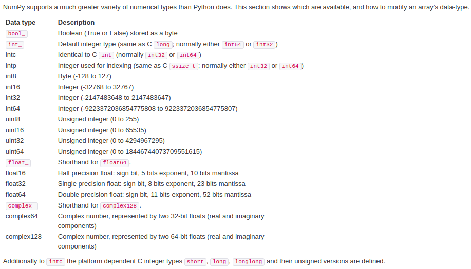

```python
Image("numpy_datatypes.png")
```

reference: https://docs.scipy.org/doc/numpy-1.13.0/user/basics.types.html

```python
x = np.array([1, 2])  # Let numpy choose the datatype
y = np.array([1.0, 2.0])  # Let numpy choose the datatype
z = np.array([1, 2], dtype=np.int64)  # Force a particular datatype

print (x.dtype, y.dtype, z.dtype)
```

```
int32 float64 int64
```

###### We can give float values and force the datatype to be int64 , this results in loss of information

```python
z1 = np.array([1.0,2.2],dtype=np.int64)
z1
```

```
array([1, 2], dtype=int64)
```

#### Converting Data Types

```python
z1.astype('float')
```

```
array([1., 2.])
```

```python
z1.astype(str)
```

```
array(['1', '2'], dtype='<U21')
```

### Array math

Basic mathematical functions operate elementwise on arrays.

```python
x = np.array([[1,2],[3,4]], dtype=np.float64)
y = np.array([[5,6],[7,8]], dtype=np.float64)
print (x)
print (y)
```

```
[[1. 2.]
 [3. 4.]]
[[5. 6.]
 [7. 8.]]
```

###### Elementwise sum; both produce the array

```python
print (x+y)
```

```
[[ 6.  8.]
 [10. 12.]]
```

```python
print (np.add(x, y))
```

```
[[ 6.  8.]
 [10. 12.]]
```

###### Elementwise difference; both produce the array

```python
print (x - y)
print (np.subtract(x, y))
```

```
[[-4. -4.]
 [-4. -4.]]
[[-4. -4.]
 [-4. -4.]]
```

###### Even comparision of two matrices/arrays works element wise

```python
print(x - y ==  np.subtract(x, y))
```

```
[[ True  True]
 [ True  True]]
```

###### Elementwise product; both produce the array , no need to specifically mention that we need matrix multiplication unlike R

```python
# Elementwise product; both produce the array
# [[ 5.0 12.0]
#  [21.0 32.0]]
print(x * y)
print(np.multiply(x, y))
```

```
[[ 5. 12.]
 [21. 32.]]
[[ 5. 12.]
 [21. 32.]]
```

###### Matrix multiplication

```python
np.dot(x,y)
```

```
array([[19., 22.],
       [43., 50.]])
```

###### Elementwise division; both produce the array

```python
# [[ 0.2         0.33333333]
#  [ 0.42857143  0.5       ]]
print (x / y)
```

```
[[0.2        0.33333333]
 [0.42857143 0.5       ]]
```

```python
print (np.divide(x, y))
```

```
[[0.2        0.33333333]
 [0.42857143 0.5       ]]
```

###### Elementwise square root; produces the array

```python
# [[ 1.          1.41421356]
#  [ 1.73205081  2.        ]]
print (np.sqrt(x))
```

```
[[1.         1.41421356]
 [1.73205081 2.        ]]
```

Numpy provides many useful functions for performing computations on arrays; one of the most useful is `sum`:

```python
x = np.array([np.random.randn(1000),np.random.randn(1000)])
print (x)
```

```
[[ 0.77234511  2.11333011  0.45900809 ...  0.08664586 -0.25103903
   1.60743948]
 [-1.13188753  0.87342555 -0.32628707 ...  0.70971849  1.18163552
  -0.93886923]]
```

###### Traditional way

```python
sum([x[i,j] for i in range(x.shape[0]) for j in range(x.shape[1])])
```

```
28.5915028349331
```

###### The 'np' Way or 'Pythonic Way'

```python
print (np.sum(x))  # Compute sum of all elements; prints "10"
```

```
28.591502834933134
```

```python
x
```

```
array([[ 0.77234511,  2.11333011,  0.45900809, ...,  0.08664586,
        -0.25103903,  1.60743948],
       [-1.13188753,  0.87342555, -0.32628707, ...,  0.70971849,
         1.18163552, -0.93886923]])
```

```python
x
```

```
array([[ 0.77234511,  2.11333011,  0.45900809, ...,  0.08664586,
        -0.25103903,  1.60743948],
       [-1.13188753,  0.87342555, -0.32628707, ...,  0.70971849,
         1.18163552, -0.93886923]])
```

```python
%%timeit -n 100
sum([x[i,j] for i in range(x.shape[0]) for j in range(x.shape[1])])
```

```
1.23 ms ± 162 µs per loop (mean ± std. dev. of 7 runs, 100 loops each)
```

```python
%%timeit -n 100
np.sum(x)
```

```
18 µs ± 4.34 µs per loop (mean ± std. dev. of 7 runs, 100 loops each)
```

Numpy also allows us to specify the axis on which we want to compute sum

```python
temp.shape
```

```
(25, 6)
```

```python
print (np.sum(temp, axis=0))  # Compute sum of each column; prints "[350. 554.   7.   3.   4.   7.]"
```

```
[350. 554.   7.   3.   4.   7.]
```

```python
print (np.sum(temp, axis=1))  # Compute sum of each row; prints "[51. 15. 47. 30. 42. 32. 45. 22. 41. 24. 60. 26. 39. 31. 41. 42. 48. 44.,45. 31. 29. 34. 37. 36. 33.]"
```

```
[51. 15. 47. 30. 42. 32. 45. 22. 41. 24. 60. 26. 39. 31. 41. 42. 48. 44.
 45. 31. 29. 34. 37. 36. 33.]
```

##### Acivities

- Extract the second Column of the temp variable and print it.
- Find the number of elements greater than 15 in the whole `temp` data.
- Find the sum of all the even and odd numbers in the $2^{nd}$ column of `temp` data.
- Subtract mean of second column from each element in the second column.
- After subtracting the mean from each value, divide each element by the standard deviation.

```python
def break_time():
    time_take_to_complete_numpy = time.time()-start
    s = time.time()

    response = input("So it's been {} minutes that we started talking about Modules and Numpy, Do you guys want a break?: \n 'Yes' or 'No' are your options by the way...".format(np.round(time_take_to_complete_numpy/60,2)))
    if response not in ['No','Yes']:
        print ("Uh Oh!, I can only take inputs mentioned, please execute the cell again and try!")
    if response == 'Yes':
        print ("Ok then!, Let's start in 15 minutes.")
    if response == 'No':
        print ("Are you sure? , Because pandas is going to be super confusing without some coffee in your stomach!")
        break_time()
```

```python
break_time()
```

```
So it's been 0.14 minutes that we started talking about Modules and Numpy, Do you guys want a break?:
 'Yes' or 'No' are your options by the way...YEs
Uh Oh!, I can only take inputs mentioned, please execute the cell again and try!
```

## Pandas

[figure not shown]

```python
from IPython.display import Image
Image("pandas.jpg")
```

```python
import numpy as np
import pandas as pd
```

The data structure in Pandas we use are

```
- 1. Series      -> 1 Dimensional
- 2. DataFrame   -> 2 Dimensional
```

Both the datastructures are mutable, meaning we can change the values in the data structure once we define them.

### Object Creation

Creating a `Series` by passing a list of values, letting pandas create a default integer index:

```python
s = pd.Series([1,3,5,np.nan,6,8]) #similar to NA in R
s
```

```
0    1.0
1    3.0
2    5.0
3    NaN
4    6.0
5    8.0
dtype: float64
```

##### We can also specify the column name while creating a dataframe

```python
data = np.random.randn(20,2)
```

```python
df = pd.DataFrame(data, index=range(20),columns=['A','B'])
df
```

|  | A | B |
| --- | --- | --- |
| 0 | 1.279484 | -1.285524 |
| 1 | 0.157297 | -0.632505 |
| 2 | -1.648124 | 0.075721 |
| 3 | 0.499915 | 2.543794 |
| 4 | 0.912736 | 0.966964 |
| 5 | -0.499517 | 0.564399 |
| 6 | 0.519285 | -0.379767 |
| 7 | 1.167475 | -0.160600 |
| 8 | -1.737394 | -0.053698 |
| 9 | -0.015865 | 0.912084 |
| 10 | -0.003309 | -0.195002 |
| 11 | 0.239074 | -0.541387 |
| 12 | 0.338840 | 0.682668 |
| 13 | 0.656998 | -0.092934 |
| 14 | -1.458603 | -0.497295 |
| 15 | -1.085803 | 0.775723 |
| 16 | 0.023574 | -1.056524 |
| 17 | -1.205735 | -0.595994 |
| 18 | 0.067652 | 1.245455 |
| 19 | -0.967207 | 0.655369 |

```python
df.dtypes
```

```
A    float64
B    float64
dtype: object
```

### Exploring Data

##### Head

In python by default the first 5 rows are printed , unlike first 6 in R

```python
df.head()
```

|  | A | B |
| --- | --- | --- |
| 0 | 1.279484 | -1.285524 |
| 1 | 0.157297 | -0.632505 |
| 2 | -1.648124 | 0.075721 |
| 3 | 0.499915 | 2.543794 |
| 4 | 0.912736 | 0.966964 |

```python
df.iloc[0:5,0:5]
```

|  | A | B |
| --- | --- | --- |
| 0 | 1.279484 | -1.285524 |
| 1 | 0.157297 | -0.632505 |
| 2 | -1.648124 | 0.075721 |
| 3 | 0.499915 | 2.543794 |
| 4 | 0.912736 | 0.966964 |

###### In python by default the last 5 rows are printed , unlike first 6 in R

```python
df.tail()
```

|  | A | B |
| --- | --- | --- |
| 15 | -1.085803 | 0.775723 |
| 16 | 0.023574 | -1.056524 |
| 17 | -1.205735 | -0.595994 |
| 18 | 0.067652 | 1.245455 |
| 19 | -0.967207 | 0.655369 |

```python
df.iloc[-5:,-5:]
```

|  | A | B |
| --- | --- | --- |
| 15 | -1.085803 | 0.775723 |
| 16 | 0.023574 | -1.056524 |
| 17 | -1.205735 | -0.595994 |
| 18 | 0.067652 | 1.245455 |
| 19 | -0.967207 | 0.655369 |

### Index

```python
df.index
```

```
RangeIndex(start=0, stop=20, step=1)
```

##### Column Names

```python
df.columns
```

```
Index(['A', 'B'], dtype='object')
```

###### Dataframe values

```python
df.values
```

```
array([[ 1.27948388, -1.28552402],
       [ 0.15729701, -0.63250541],
       [-1.64812358,  0.07572112],
       [ 0.49991526,  2.5437941 ],
       [ 0.91273573,  0.96696431],
       [-0.49951654,  0.56439872],
       [ 0.51928487, -0.37976706],
       [ 1.16747499, -0.16059956],
       [-1.73739413, -0.05369831],
       [-0.0158653 ,  0.91208434],
       [-0.00330923, -0.19500195],
       [ 0.23907418, -0.54138664],
       [ 0.33884001,  0.68266766],
       [ 0.65699816, -0.09293382],
       [-1.45860323, -0.49729495],
       [-1.08580252,  0.77572291],
       [ 0.02357373, -1.05652414],
       [-1.20573485, -0.59599354],
       [ 0.06765172,  1.24545477],
       [-0.96720663,  0.65536936]])
```

###### Describe shows a quick statistic summary of your data

```python
df.describe() # similar to summary() in R
```

|  | A | B |
| --- | --- | --- |
| count | 20.000000 | 20.000000 |
| mean | -0.137961 | 0.146547 |
| std | 0.925827 | 0.902192 |
| min | -1.737394 | -1.285524 |
| 25% | -0.996856 | -0.508318 |
| 50% | 0.045613 | -0.073316 |
| 75% | 0.504758 | 0.705931 |
| max | 1.279484 | 2.543794 |

###### Transposing your data

```python
df.T
```

|  | 0 | 1 | 2 | 3 | 4 | 5 | 6 | 7 | 8 | 9 | 10 | 11 | 12 | 13 | 14 | 15 | 16 | 17 | 18 | 19 |
| --- | --- | --- | --- | --- | --- | --- | --- | --- | --- | --- | --- | --- | --- | --- | --- | --- | --- | --- | --- | --- |
| A | 1.279484 | 0.157297 | -1.648124 | 0.499915 | 0.912736 | -0.499517 | 0.519285 | 1.167475 | -1.737394 | -0.015865 | -0.003309 | 0.239074 | 0.338840 | 0.656998 | -1.458603 | -1.085803 | 0.023574 | -1.205735 | 0.067652 | -0.967207 |
| B | -1.285524 | -0.632505 | 0.075721 | 2.543794 | 0.966964 | 0.564399 | -0.379767 | -0.160600 | -0.053698 | 0.912084 | -0.195002 | -0.541387 | 0.682668 | -0.092934 | -0.497295 | 0.775723 | -1.056524 | -0.595994 | 1.245455 | 0.655369 |

## Sorting by an axis

```python
df.sort_index(ascending=False) # based on rows , default tries to sort the index
```

|  | A | B |
| --- | --- | --- |
| 19 | -0.967207 | 0.655369 |
| 18 | 0.067652 | 1.245455 |
| 17 | -1.205735 | -0.595994 |
| 16 | 0.023574 | -1.056524 |
| 15 | -1.085803 | 0.775723 |
| 14 | -1.458603 | -0.497295 |
| 13 | 0.656998 | -0.092934 |
| 12 | 0.338840 | 0.682668 |
| 11 | 0.239074 | -0.541387 |
| 10 | -0.003309 | -0.195002 |
| 9 | -0.015865 | 0.912084 |
| 8 | -1.737394 | -0.053698 |
| 7 | 1.167475 | -0.160600 |
| 6 | 0.519285 | -0.379767 |
| 5 | -0.499517 | 0.564399 |
| 4 | 0.912736 | 0.966964 |
| 3 | 0.499915 | 2.543794 |
| 2 | -1.648124 | 0.075721 |
| 1 | 0.157297 | -0.632505 |
| 0 | 1.279484 | -1.285524 |

##### If we want to sort out dataframe based on a single column

```python
df.sort_index(axis=0, ascending=False,by='A')
```

|  | A | B |
| --- | --- | --- |
| 0 | 1.279484 | -1.285524 |
| 7 | 1.167475 | -0.160600 |
| 4 | 0.912736 | 0.966964 |
| 13 | 0.656998 | -0.092934 |
| 6 | 0.519285 | -0.379767 |
| 3 | 0.499915 | 2.543794 |
| 12 | 0.338840 | 0.682668 |
| 11 | 0.239074 | -0.541387 |
| 1 | 0.157297 | -0.632505 |
| 18 | 0.067652 | 1.245455 |
| 16 | 0.023574 | -1.056524 |
| 10 | -0.003309 | -0.195002 |
| 9 | -0.015865 | 0.912084 |
| 5 | -0.499517 | 0.564399 |
| 19 | -0.967207 | 0.655369 |
| 15 | -1.085803 | 0.775723 |
| 17 | -1.205735 | -0.595994 |
| 14 | -1.458603 | -0.497295 |
| 2 | -1.648124 | 0.075721 |
| 8 | -1.737394 | -0.053698 |

```python
df.sort_index(axis=1, ascending=False) # Sort based on columns, again,by default sorts the col names
```

|  | B | A |
| --- | --- | --- |
| 0 | -1.285524 | 1.279484 |
| 1 | -0.632505 | 0.157297 |
| 2 | 0.075721 | -1.648124 |
| 3 | 2.543794 | 0.499915 |
| 4 | 0.966964 | 0.912736 |
| 5 | 0.564399 | -0.499517 |
| 6 | -0.379767 | 0.519285 |
| 7 | -0.160600 | 1.167475 |
| 8 | -0.053698 | -1.737394 |
| 9 | 0.912084 | -0.015865 |
| 10 | -0.195002 | -0.003309 |
| 11 | -0.541387 | 0.239074 |
| 12 | 0.682668 | 0.338840 |
| 13 | -0.092934 | 0.656998 |
| 14 | -0.497295 | -1.458603 |
| 15 | 0.775723 | -1.085803 |
| 16 | -1.056524 | 0.023574 |
| 17 | -0.595994 | -1.205735 |
| 18 | 1.245455 | 0.067652 |
| 19 | 0.655369 | -0.967207 |

### Selection ( Also called indexing)

#### Selection by Position

###### .iloc is primarily integer position based (from 0 to length of the axis -1 ), but may also be used with a boolean array.

.iloc will raise IndexError if a requested indexer is out-of-bounds, except slice indexers which allow out-of-bounds indexing.

```python
# df.iloc[35,:]
```

```python
df.iloc[3:5,0:2]
```

|  | A | B |
| --- | --- | --- |
| 3 | 0.499915 | 2.543794 |
| 4 | 0.912736 | 0.966964 |

### Selection by Label

##### .loc is primarily label based, but may also be used with a boolean array. .loc will raise KeyError when the items are not found.

##### Showing label slicing, both endpoints are included

```python
df.loc[range(3),['A','B']]
```

|  | A | B |
| --- | --- | --- |
| 0 | 1.279484 | -1.285524 |
| 1 | 0.157297 | -0.632505 |
| 2 | -1.648124 | 0.075721 |

# Let us try our hand at a dataset

#### Load data

###### german credit data 1

```python
import pandas as pd
```

```python
german_credit_1 = pd.read_csv("./German-Credit_1.csv")
```

#### Exploration

##### Print the column names for the dataset

```python
german_credit_1.columns
```

```
Index(['OBS', 'DURATION', 'NEW_CAR', 'USED_CAR', 'FURNITURE', 'RADIO_TV',
       'EDUCATION', 'RETRAINING', 'AMOUNT', 'INSTALL_RATE', 'CO_APPLICANT',
       'GUARANTOR', 'REAL_ESTATE', 'PROP_UNKN_NONE', 'AGE', 'OTHER_INSTALL',
       'RENT', 'OWN_RES', 'NUM_CREDITS', 'NUM_DEPENDENTS', 'TELEPHONE',
       'FOREIGN', 'RESPONSE'],
      dtype='object')
```

##### Print the data types for the dataset

```python
german_credit_1.dtypes
```

```
OBS                 int64
DURATION          float64
NEW_CAR           float64
USED_CAR          float64
FURNITURE         float64
RADIO_TV          float64
EDUCATION         float64
RETRAINING        float64
AMOUNT            float64
INSTALL_RATE      float64
CO_APPLICANT      float64
GUARANTOR         float64
REAL_ESTATE       float64
PROP_UNKN_NONE    float64
AGE               float64
OTHER_INSTALL     float64
RENT              float64
OWN_RES           float64
NUM_CREDITS       float64
NUM_DEPENDENTS    float64
TELEPHONE         float64
FOREIGN           float64
RESPONSE          float64
dtype: object
```

##### Print the first few columns of the dataset

```python
german_credit_1.head()
```

|  | OBS | DURATION | NEW_CAR | USED_CAR | FURNITURE | RADIO_TV | EDUCATION | RETRAINING | AMOUNT | INSTALL_RATE | ... | PROP_UNKN_NONE | AGE | OTHER_INSTALL | RENT | OWN_RES | NUM_CREDITS | NUM_DEPENDENTS | TELEPHONE | FOREIGN | RESPONSE |
| --- | --- | --- | --- | --- | --- | --- | --- | --- | --- | --- | --- | --- | --- | --- | --- | --- | --- | --- | --- | --- | --- |
| 0 | 1 | 6.0 | 0.0 | 0.0 | 0.0 | 1.0 | 0.0 | 0.0 | 1169.0 | 4.0 | ... | 0.0 | 67.0 | 0.0 | 0.0 | 1.0 | 2.0 | 1.0 | 1.0 | 0.0 | 1.0 |
| 1 | 2 | 48.0 | 0.0 | 0.0 | 0.0 | 1.0 | 0.0 | 0.0 | 5951.0 | 2.0 | ... | 0.0 | 22.0 | 0.0 | 0.0 | 1.0 | 1.0 | 1.0 | 0.0 | 0.0 | 0.0 |
| 2 | 3 | 12.0 | 0.0 | 0.0 | 0.0 | 0.0 | 1.0 | 0.0 | 2096.0 | 2.0 | ... | 0.0 | 49.0 | 0.0 | 0.0 | 1.0 | 1.0 | 2.0 | 0.0 | 0.0 | 1.0 |
| 3 | 4 | 42.0 | 0.0 | 0.0 | 1.0 | 0.0 | 0.0 | 0.0 | 7882.0 | 2.0 | ... | 0.0 | 45.0 | 0.0 | 0.0 | 0.0 | 1.0 | 2.0 | 0.0 | 0.0 | 1.0 |
| 4 | 5 | 24.0 | 1.0 | 0.0 | 0.0 | 0.0 | 0.0 | 0.0 | 4870.0 | 3.0 | ... | 1.0 | 53.0 | 0.0 | 0.0 | 0.0 | 2.0 | 2.0 | 0.0 | 0.0 | 0.0 |

5 rows × 23 columns

##### Print the first few columns of the dataset

```python
german_credit_1.head()
```

|  | OBS | DURATION | NEW_CAR | USED_CAR | FURNITURE | RADIO_TV | EDUCATION | RETRAINING | AMOUNT | INSTALL_RATE | ... | PROP_UNKN_NONE | AGE | OTHER_INSTALL | RENT | OWN_RES | NUM_CREDITS | NUM_DEPENDENTS | TELEPHONE | FOREIGN | RESPONSE |
| --- | --- | --- | --- | --- | --- | --- | --- | --- | --- | --- | --- | --- | --- | --- | --- | --- | --- | --- | --- | --- | --- |
| 0 | 1 | 6.0 | 0.0 | 0.0 | 0.0 | 1.0 | 0.0 | 0.0 | 1169.0 | 4.0 | ... | 0.0 | 67.0 | 0.0 | 0.0 | 1.0 | 2.0 | 1.0 | 1.0 | 0.0 | 1.0 |
| 1 | 2 | 48.0 | 0.0 | 0.0 | 0.0 | 1.0 | 0.0 | 0.0 | 5951.0 | 2.0 | ... | 0.0 | 22.0 | 0.0 | 0.0 | 1.0 | 1.0 | 1.0 | 0.0 | 0.0 | 0.0 |
| 2 | 3 | 12.0 | 0.0 | 0.0 | 0.0 | 0.0 | 1.0 | 0.0 | 2096.0 | 2.0 | ... | 0.0 | 49.0 | 0.0 | 0.0 | 1.0 | 1.0 | 2.0 | 0.0 | 0.0 | 1.0 |
| 3 | 4 | 42.0 | 0.0 | 0.0 | 1.0 | 0.0 | 0.0 | 0.0 | 7882.0 | 2.0 | ... | 0.0 | 45.0 | 0.0 | 0.0 | 0.0 | 1.0 | 2.0 | 0.0 | 0.0 | 1.0 |
| 4 | 5 | 24.0 | 1.0 | 0.0 | 0.0 | 0.0 | 0.0 | 0.0 | 4870.0 | 3.0 | ... | 1.0 | 53.0 | 0.0 | 0.0 | 0.0 | 2.0 | 2.0 | 0.0 | 0.0 | 0.0 |

5 rows × 23 columns

###### Check the shape of the data set

```python
german_credit_1.shape
```

```
(1000, 23)
```

```python
german_credit_2 = pd.read_csv("./German-Credit_2.csv")
```

```python
german_credit_2.shape
```

```
(1000, 7)
```

```python
german_credit_2.head()
```

|  | OBS | CHK_ACCT | HISTORY | SAV_ACCT | EMPLOYMENT | PRESENT_RESIDENT | JOB |
| --- | --- | --- | --- | --- | --- | --- | --- |
| 0 | 1 | 0 | 4 | 4 | 4 | 4 | 2 |
| 1 | 2 | 1 | 2 | 0 | 2 | 2 | 2 |
| 2 | 3 | 3 | 4 | 0 | 3 | 3 | 1 |
| 3 | 4 | 0 | 2 | 0 | 3 | 4 | 2 |
| 4 | 5 | 0 | 3 | 0 | 2 | 4 | 2 |

```python
df3 = german_credit_1.merge(german_credit_2,on=['OBS'])
```

```python
df3.shape
```

```
(1000, 29)
```

###### Numeric attributes

```python
num_attr = ["DURATION","AMOUNT","INSTALL_RATE","AGE","NUM_CREDITS","NUM_DEPENDENTS"]
```

```python
num_attr
```

```
['DURATION', 'AMOUNT', 'INSTALL_RATE', 'AGE', 'NUM_CREDITS', 'NUM_DEPENDENTS']
```

```python
cat_attr = [i for i in df3.columns.values if i not in num_attr]
```

```python
cat_attr
```

```
['OBS',
 'NEW_CAR',
 'USED_CAR',
 'FURNITURE',
 'RADIO_TV',
 'EDUCATION',
 'RETRAINING',
 'CO_APPLICANT',
 'GUARANTOR',
 'REAL_ESTATE',
 'PROP_UNKN_NONE',
 'OTHER_INSTALL',
 'RENT',
 'OWN_RES',
 'TELEPHONE',
 'FOREIGN',
 'RESPONSE',
 'CHK_ACCT',
 'HISTORY',
 'SAV_ACCT',
 'EMPLOYMENT',
 'PRESENT_RESIDENT',
 'JOB']
```

##### apply function(to convert all categorical attributes to factors)

```python
def convert_to_categorical(dataset,col_names_to_convert):
    for i in col_names_to_convert:
        dataset[i] = dataset[i].astype(str)
    return(dataset)
```

```python
df3 = convert_to_categorical(df3,col_names_to_convert=cat_attr)
```

```python
df3.dtypes
```

```
OBS                  object
DURATION            float64
NEW_CAR              object
USED_CAR             object
FURNITURE            object
RADIO_TV             object
EDUCATION            object
RETRAINING           object
AMOUNT              float64
INSTALL_RATE        float64
CO_APPLICANT         object
GUARANTOR            object
REAL_ESTATE          object
PROP_UNKN_NONE       object
AGE                 float64
OTHER_INSTALL        object
RENT                 object
OWN_RES              object
NUM_CREDITS         float64
NUM_DEPENDENTS      float64
TELEPHONE            object
FOREIGN              object
RESPONSE             object
CHK_ACCT             object
HISTORY              object
SAV_ACCT             object
EMPLOYMENT           object
PRESENT_RESIDENT     object
JOB                  object
dtype: object
```

#### Data exploration

```python
df3.describe()
```

|  | DURATION | AMOUNT | INSTALL_RATE | AGE | NUM_CREDITS | NUM_DEPENDENTS |
| --- | --- | --- | --- | --- | --- | --- |
| count | 998.000000 | 990.000000 | 993.000000 | 990.000000 | 994.000000 | 993.000000 |
| mean | 20.917836 | 3273.168687 | 2.972810 | 35.505051 | 1.406439 | 1.156093 |
| std | 12.064656 | 2826.183525 | 1.119055 | 11.342694 | 0.576302 | 0.363126 |
| min | 4.000000 | 250.000000 | 1.000000 | 19.000000 | 1.000000 | 1.000000 |
| 25% | 12.000000 | 1371.250000 | 2.000000 | 27.000000 | 1.000000 | 1.000000 |
| 50% | 18.000000 | 2321.500000 | 3.000000 | 33.000000 | 1.000000 | 1.000000 |
| 75% | 24.000000 | 3970.500000 | 4.000000 | 42.000000 | 2.000000 | 1.000000 |
| max | 72.000000 | 18424.000000 | 4.000000 | 75.000000 | 4.000000 | 2.000000 |

```python
df3.describe(include=[np.object]).transpose() # to include the categorical columns?
```

|  | count | unique | top | freq |
| --- | --- | --- | --- | --- |
| OBS | 1000 | 1000 | 614 | 1 |
| NEW_CAR | 1000 | 3 | 0.0 | 765 |
| USED_CAR | 1000 | 3 | 0.0 | 896 |
| FURNITURE | 1000 | 3 | 0.0 | 819 |
| RADIO_TV | 1000 | 3 | 0.0 | 718 |
| EDUCATION | 1000 | 3 | 0.0 | 946 |
| RETRAINING | 1000 | 3 | 0.0 | 899 |
| CO_APPLICANT | 1000 | 3 | 0.0 | 951 |
| GUARANTOR | 1000 | 3 | 0.0 | 941 |
| REAL_ESTATE | 1000 | 3 | 0.0 | 713 |
| PROP_UNKN_NONE | 1000 | 3 | 0.0 | 839 |
| OTHER_INSTALL | 1000 | 3 | 0.0 | 806 |
| RENT | 1000 | 3 | 0.0 | 815 |
| OWN_RES | 1000 | 3 | 1.0 | 709 |
| TELEPHONE | 1000 | 3 | 0.0 | 594 |
| FOREIGN | 1000 | 3 | 0.0 | 957 |
| RESPONSE | 1000 | 3 | 1.0 | 698 |
| CHK_ACCT | 1000 | 4 | 3 | 394 |
| HISTORY | 1000 | 5 | 2 | 530 |
| SAV_ACCT | 1000 | 5 | 0 | 603 |
| EMPLOYMENT | 1000 | 5 | 2 | 339 |
| PRESENT_RESIDENT | 1000 | 4 | 4 | 413 |
| JOB | 1000 | 4 | 2 | 630 |

##### Pandas DataFrame Methods

Some methods in pandas dataframes we generally use

- pandas.DataFrame.max — finds the highest value in each column.
- pandas.DataFrame.min — finds the lowest value in each column.
- pandas.DataFrame.median — finds the median of each column.
- pandas.DataFrame.std — finds the standard deviation of each column.

```python
df3.AGE.max()
```

```
75.0
```

```python
df3.AGE.min()
```

```
19.0
```

```python
df3.AGE.mean()
```

```
35.505050505050505
```

```python
df3.AGE.median()
```

```
33.0
```

```python
df3.AGE.std()
```

```
11.342693614402492
```

##### Checking Number of unique values/levels

```python
for i in df3.columns:
    n = np.unique(df3[i])
    print([i,len(n)])
```

```
['OBS', 1000]
['DURATION', 35]
['NEW_CAR', 3]
['USED_CAR', 3]
['FURNITURE', 3]
['RADIO_TV', 3]
['EDUCATION', 3]
['RETRAINING', 3]
['AMOUNT', 922]
['INSTALL_RATE', 11]
['CO_APPLICANT', 3]
['GUARANTOR', 3]
['REAL_ESTATE', 3]
['PROP_UNKN_NONE', 3]
['AGE', 63]
['OTHER_INSTALL', 3]
['RENT', 3]
['OWN_RES', 3]
['NUM_CREDITS', 10]
['NUM_DEPENDENTS', 9]
['TELEPHONE', 3]
['FOREIGN', 3]
['RESPONSE', 3]
['CHK_ACCT', 4]
['HISTORY', 5]
['SAV_ACCT', 5]
['EMPLOYMENT', 5]
['PRESENT_RESIDENT', 4]
['JOB', 4]
```

```python
temp = df3.copy()
```

```python
#Subsetting data:
# dropping 1st and 2nd column
temp.drop(['OBS','DURATION'],inplace=True,axis=1)
```

```python
temp.columns
```

```
Index(['NEW_CAR', 'USED_CAR', 'FURNITURE', 'RADIO_TV', 'EDUCATION',
       'RETRAINING', 'AMOUNT', 'INSTALL_RATE', 'CO_APPLICANT', 'GUARANTOR',
       'REAL_ESTATE', 'PROP_UNKN_NONE', 'AGE', 'OTHER_INSTALL', 'RENT',
       'OWN_RES', 'NUM_CREDITS', 'NUM_DEPENDENTS', 'TELEPHONE', 'FOREIGN',
       'RESPONSE', 'CHK_ACCT', 'HISTORY', 'SAV_ACCT', 'EMPLOYMENT',
       'PRESENT_RESIDENT', 'JOB'],
      dtype='object')
```

```python
df3.columns
```

```
Index(['OBS', 'DURATION', 'NEW_CAR', 'USED_CAR', 'FURNITURE', 'RADIO_TV',
       'EDUCATION', 'RETRAINING', 'AMOUNT', 'INSTALL_RATE', 'CO_APPLICANT',
       'GUARANTOR', 'REAL_ESTATE', 'PROP_UNKN_NONE', 'AGE', 'OTHER_INSTALL',
       'RENT', 'OWN_RES', 'NUM_CREDITS', 'NUM_DEPENDENTS', 'TELEPHONE',
       'FOREIGN', 'RESPONSE', 'CHK_ACCT', 'HISTORY', 'SAV_ACCT', 'EMPLOYMENT',
       'PRESENT_RESIDENT', 'JOB'],
      dtype='object')
```

```python
# selecting 1st and 2nd row
df3.iloc[0:2,:]
```

|  | OBS | DURATION | NEW_CAR | USED_CAR | FURNITURE | RADIO_TV | EDUCATION | RETRAINING | AMOUNT | INSTALL_RATE | ... | NUM_DEPENDENTS | TELEPHONE | FOREIGN | RESPONSE | CHK_ACCT | HISTORY | SAV_ACCT | EMPLOYMENT | PRESENT_RESIDENT | JOB |
| --- | --- | --- | --- | --- | --- | --- | --- | --- | --- | --- | --- | --- | --- | --- | --- | --- | --- | --- | --- | --- | --- |
| 0 | 1 | 6.0 | 0.0 | 0.0 | 0.0 | 1.0 | 0.0 | 0.0 | 1169.0 | 4.0 | ... | 1.0 | 1.0 | 0.0 | 1.0 | 0 | 4 | 4 | 4 | 4 | 2 |
| 1 | 2 | 48.0 | 0.0 | 0.0 | 0.0 | 1.0 | 0.0 | 0.0 | 5951.0 | 2.0 | ... | 1.0 | 0.0 | 0.0 | 0.0 | 1 | 2 | 0 | 2 | 2 | 2 |

2 rows × 29 columns

### Finding outliers

###### Threshold method

```python
import numpy as np
def outliers_z_score(ys,threshold = 3):
    """ This function takes a numeric column and returns the outliers.
    Default threshold is 3, but takes any integer or float value"""
    mean_y = np.mean(ys)
    stdev_y = np.std(ys)
    z_scores = [(y - mean_y) / stdev_y for y in ys]
    return np.where(np.abs(z_scores) > threshold)
```

```python
df3.loc[:,num_attr].apply(outliers_z_score)
```

```
DURATION          ([29, 134, 255, 332, 373, 374, 616, 637, 672, ...
AMOUNT            ([18, 63, 87, 95, 105, 236, 272, 274, 373, 374...
INSTALL_RATE                                                  ([],)
AGE                          ([163, 186, 330, 430, 536, 606, 756],)
NUM_CREDITS                        ([65, 197, 590, 653, 807, 890],)
NUM_DEPENDENTS                                                ([],)
dtype: object
```

###### IQR method

```python
import numpy as np
def outliers_iqr(ys):
    quartile_1, quartile_3 = np.percentile(ys, [25, 75])
    iqr = quartile_3 - quartile_1
    lower_bound = quartile_1 - (iqr * 1.5)
    upper_bound = quartile_3 + (iqr * 1.5)
    return np.where((ys > upper_bound) | (ys < lower_bound))
```

```python
df3.loc[:,num_attr].apply(outliers_iqr)
```

```
DURATION          ([],)
AMOUNT            ([],)
INSTALL_RATE      ([],)
AGE               ([],)
NUM_CREDITS       ([],)
NUM_DEPENDENTS    ([],)
dtype: object
```

##### Handling Missing values

```python
#To check null values in data
```

```python
df3.isnull()
```

|  | OBS | DURATION | NEW_CAR | USED_CAR | FURNITURE | RADIO_TV | EDUCATION | RETRAINING | AMOUNT | INSTALL_RATE | ... | NUM_DEPENDENTS | TELEPHONE | FOREIGN | RESPONSE | CHK_ACCT | HISTORY | SAV_ACCT | EMPLOYMENT | PRESENT_RESIDENT | JOB |
| --- | --- | --- | --- | --- | --- | --- | --- | --- | --- | --- | --- | --- | --- | --- | --- | --- | --- | --- | --- | --- | --- |
| 0 | False | False | False | False | False | False | False | False | False | False | ... | False | False | False | False | False | False | False | False | False | False |
| 1 | False | False | False | False | False | False | False | False | False | False | ... | False | False | False | False | False | False | False | False | False | False |
| 2 | False | False | False | False | False | False | False | False | False | False | ... | False | False | False | False | False | False | False | False | False | False |
| 3 | False | False | False | False | False | False | False | False | False | False | ... | False | False | False | False | False | False | False | False | False | False |
| 4 | False | False | False | False | False | False | False | False | False | False | ... | False | False | False | False | False | False | False | False | False | False |
| 5 | False | False | False | False | False | False | False | False | False | False | ... | False | False | False | False | False | False | False | False | False | False |
| 6 | False | False | False | False | False | False | False | False | False | False | ... | False | False | False | False | False | False | False | False | False | False |
| 7 | False | False | False | False | False | False | False | False | False | False | ... | False | False | False | False | False | False | False | False | False | False |
| 8 | False | False | False | False | False | False | False | False | False | False | ... | False | False | False | False | False | False | False | False | False | False |
| 9 | False | False | False | False | False | False | False | False | False | False | ... | False | False | False | False | False | False | False | False | False | False |
| 10 | False | False | False | False | False | False | False | False | False | False | ... | False | False | False | False | False | False | False | False | False | False |
| 11 | False | False | False | False | False | False | False | False | False | False | ... | False | False | False | False | False | False | False | False | False | False |
| 12 | False | False | False | False | False | False | False | False | False | False | ... | False | False | False | False | False | False | False | False | False | False |
| 13 | False | False | False | False | False | False | False | False | True | False | ... | True | False | False | False | False | False | False | False | False | False |
| 14 | False | False | False | False | False | False | False | False | False | False | ... | False | False | False | False | False | False | False | False | False | False |
| 15 | False | False | False | False | False | False | False | False | False | False | ... | False | False | False | False | False | False | False | False | False | False |
| 16 | False | False | False | False | False | False | False | False | False | False | ... | False | False | False | False | False | False | False | False | False | False |
| 17 | False | False | False | False | False | False | False | False | False | False | ... | False | False | False | False | False | False | False | False | False | False |
| 18 | False | False | False | False | False | False | False | False | False | False | ... | False | False | False | False | False | False | False | False | False | False |
| 19 | False | False | False | False | False | False | False | False | False | False | ... | False | False | False | False | False | False | False | False | False | False |
| 20 | False | False | False | False | False | False | False | False | True | True | ... | True | False | False | False | False | False | False | False | False | False |
| 21 | False | False | False | False | False | False | False | False | False | False | ... | False | False | False | False | False | False | False | False | False | False |
| 22 | False | False | False | False | False | False | False | False | False | False | ... | False | False | False | False | False | False | False | False | False | False |
| 23 | False | False | False | False | False | False | False | False | False | False | ... | False | False | False | False | False | False | False | False | False | False |
| 24 | False | False | False | False | False | False | False | False | False | False | ... | False | False | False | False | False | False | False | False | False | False |
| 25 | False | False | False | False | False | False | False | False | False | False | ... | False | False | False | False | False | False | False | False | False | False |
| 26 | False | False | False | False | False | False | False | False | True | True | ... | False | False | False | False | False | False | False | False | False | False |
| 27 | False | False | False | False | False | False | False | False | False | False | ... | False | False | False | False | False | False | False | False | False | False |
| 28 | False | False | False | False | False | False | False | False | False | False | ... | False | False | False | False | False | False | False | False | False | False |
| 29 | False | False | False | False | False | False | False | False | False | False | ... | False | False | False | False | False | False | False | False | False | False |
| ... | ... | ... | ... | ... | ... | ... | ... | ... | ... | ... | ... | ... | ... | ... | ... | ... | ... | ... | ... | ... | ... |
| 970 | False | False | False | False | False | False | False | False | False | False | ... | False | False | False | False | False | False | False | False | False | False |
| 971 | False | False | False | False | False | False | False | False | False | False | ... | False | False | False | False | False | False | False | False | False | False |
| 972 | False | False | False | False | False | False | False | False | False | False | ... | False | False | False | False | False | False | False | False | False | False |
| 973 | False | False | False | False | False | False | False | False | False | False | ... | False | False | False | False | False | False | False | False | False | False |
| 974 | False | False | False | False | False | False | False | False | False | False | ... | False | False | False | False | False | False | False | False | False | False |
| 975 | False | False | False | False | False | False | False | False | False | False | ... | False | False | False | False | False | False | False | False | False | False |
| 976 | False | False | False | False | False | False | False | False | False | False | ... | False | False | False | False | False | False | False | False | False | False |
| 977 | False | False | False | False | False | False | False | False | False | False | ... | False | False | False | False | False | False | False | False | False | False |
| 978 | False | False | False | False | False | False | False | False | False | False | ... | False | False | False | False | False | False | False | False | False | False |
| 979 | False | False | False | False | False | False | False | False | False | False | ... | False | False | False | False | False | False | False | False | False | False |
| 980 | False | False | False | False | False | False | False | False | True | True | ... | False | False | False | False | False | False | False | False | False | False |
| 981 | False | False | False | False | False | False | False | False | False | False | ... | False | False | False | False | False | False | False | False | False | False |
| 982 | False | False | False | False | False | False | False | False | False | False | ... | False | False | False | False | False | False | False | False | False | False |
| 983 | False | False | False | False | False | False | False | False | False | False | ... | False | False | False | False | False | False | False | False | False | False |
| 984 | False | False | False | False | False | False | False | False | False | False | ... | False | False | False | False | False | False | False | False | False | False |
| 985 | False | False | False | False | False | False | False | False | False | False | ... | False | False | False | False | False | False | False | False | False | False |
| 986 | False | False | False | False | False | False | False | False | False | False | ... | False | False | False | False | False | False | False | False | False | False |
| 987 | False | False | False | False | False | False | False | False | False | False | ... | False | False | False | False | False | False | False | False | False | False |
| 988 | False | False | False | False | False | False | False | False | False | False | ... | False | False | False | False | False | False | False | False | False | False |
| 989 | False | False | False | False | False | False | False | False | False | False | ... | False | False | False | False | False | False | False | False | False | False |
| 990 | False | False | False | False | False | False | False | False | False | False | ... | False | False | False | False | False | False | False | False | False | False |
| 991 | False | False | False | False | False | False | False | False | False | False | ... | False | False | False | False | False | False | False | False | False | False |
| 992 | False | False | False | False | False | False | False | False | False | False | ... | False | False | False | False | False | False | False | False | False | False |
| 993 | False | False | False | False | False | False | False | False | False | False | ... | False | False | False | False | False | False | False | False | False | False |
| 994 | False | False | False | False | False | False | False | False | False | False | ... | False | False | False | False | False | False | False | False | False | False |
| 995 | False | False | False | False | False | False | False | False | True | True | ... | True | False | False | False | False | False | False | False | False | False |
| 996 | False | False | False | False | False | False | False | False | False | False | ... | False | False | False | False | False | False | False | False | False | False |
| 997 | False | False | False | False | False | False | False | False | False | False | ... | False | False | False | False | False | False | False | False | False | False |
| 998 | False | False | False | False | False | False | False | False | False | False | ... | False | False | False | False | False | False | False | False | False | False |
| 999 | False | False | False | False | False | False | False | False | True | False | ... | False | False | False | False | False | False | False | False | False | False |

1000 rows × 29 columns

```python
df3.isnull().sum()
```

```
OBS                  0
DURATION             2
NEW_CAR              0
USED_CAR             0
FURNITURE            0
RADIO_TV             0
EDUCATION            0
RETRAINING           0
AMOUNT              10
INSTALL_RATE         7
CO_APPLICANT         0
GUARANTOR            0
REAL_ESTATE          0
PROP_UNKN_NONE       0
AGE                 10
OTHER_INSTALL        0
RENT                 0
OWN_RES              0
NUM_CREDITS          6
NUM_DEPENDENTS       7
TELEPHONE            0
FOREIGN              0
RESPONSE             0
CHK_ACCT             0
HISTORY              0
SAV_ACCT             0
EMPLOYMENT           0
PRESENT_RESIDENT     0
JOB                  0
dtype: int64
```

```python
# function to identify columns with na values
def na_column_names(dataset,per = 0):
    na_cols = dataset.isnull().sum()[dataset.isnull().sum()>per]
    return(list(na_cols.index))
```

```python
na_column_names(df3)
```

```
['DURATION', 'AMOUNT', 'INSTALL_RATE', 'AGE', 'NUM_CREDITS', 'NUM_DEPENDENTS']
```

##### Dropping the records with missing values

```python
temp = df3.dropna()
```

```python
# Looking at the dimension
temp.shape
```

```
(986, 29)
```

```python
df3.dropna(thresh=25,axis=0).shape #Keep only the rows with at least 25 non-na values
```

```
(996, 29)
```

### Imputing missing values

##### Imputing Numeric Columns

```python
from sklearn.preprocessing import Imputer
```

```python
imp_num = Imputer(missing_values='NaN', strategy='mean', axis=0) #Create an imputer object
```

```python
df_num_nans_imputed = pd.DataFrame(imp_num.fit_transform(df3[num_attr]), columns=num_attr) #fit and transform
```

```python
df_num_nans_imputed.isnull().sum()
```

```
DURATION          0
AMOUNT            0
INSTALL_RATE      0
AGE               0
NUM_CREDITS       0
NUM_DEPENDENTS    0
dtype: int64
```

##### Imputing Categorical columns with mode

```python
df3[cat_attr].dtypes
```

```
OBS                 object
NEW_CAR             object
USED_CAR            object
FURNITURE           object
RADIO_TV            object
EDUCATION           object
RETRAINING          object
CO_APPLICANT        object
GUARANTOR           object
REAL_ESTATE         object
PROP_UNKN_NONE      object
OTHER_INSTALL       object
RENT                object
OWN_RES             object
TELEPHONE           object
FOREIGN             object
RESPONSE            object
CHK_ACCT            object
HISTORY             object
SAV_ACCT            object
EMPLOYMENT          object
PRESENT_RESIDENT    object
JOB                 object
dtype: object
```

when we convered the columns in to string type, nan will be treated as a string, we will replace the string with pythons inbuilt null type

```python
df3[cat_attr] = df3[cat_attr].replace('nan',np.NaN)
```

```python
df_cat_nans_imputed = df3[cat_attr].apply(lambda x:x.fillna(x.value_counts().index[0]))
```

```python
df_imputed = pd.concat([df_num_nans_imputed,df_cat_nans_imputed],axis=1)
```

```python
df_imputed.columns
```

```
Index(['DURATION', 'AMOUNT', 'INSTALL_RATE', 'AGE', 'NUM_CREDITS',
       'NUM_DEPENDENTS', 'OBS', 'NEW_CAR', 'USED_CAR', 'FURNITURE', 'RADIO_TV',
       'EDUCATION', 'RETRAINING', 'CO_APPLICANT', 'GUARANTOR', 'REAL_ESTATE',
       'PROP_UNKN_NONE', 'OTHER_INSTALL', 'RENT', 'OWN_RES', 'TELEPHONE',
       'FOREIGN', 'RESPONSE', 'CHK_ACCT', 'HISTORY', 'SAV_ACCT', 'EMPLOYMENT',
       'PRESENT_RESIDENT', 'JOB'],
      dtype='object')
```

```python
df_imputed.shape
```

```
(1000, 29)
```

```python
df3.shape
```

```
(1000, 29)
```

##### Discretizing the variable

```python
bin_cutoffs =[i for i in range(0,np.max(df_imputed.AMOUNT.astype("int64")),2000)]
```

```python
bin_cutoffs,len(bin_cutoffs)
```

```
([0, 2000, 4000, 6000, 8000, 10000, 12000, 14000, 16000, 18000], 10)
```

###### returns an array showing the bin number to which each value belongs to

```python
bin_numbers = np.digitize(df_imputed.AMOUNT.astype("int64"),bins=bin_cutoffs)
```

```python
for i in zip(df_imputed.AMOUNT,bin_numbers):
    print(i)
```

```
(1169.0, 1)
(5951.0, 3)
(2096.0, 2)
(7882.0, 4)
(4870.0, 3)
(9055.0, 5)
(2835.0, 2)
(6948.0, 4)
(3059.0, 2)
(5234.0, 3)
(1295.0, 1)
(4308.0, 3)
(1567.0, 1)
(3273.168686868687, 2)
(1403.0, 1)
(1282.0, 1)
(2424.0, 2)
(8072.0, 5)
(12579.0, 7)
(3430.0, 2)
(3273.168686868687, 2)
(2647.0, 2)
(2241.0, 2)
(1804.0, 1)
(2069.0, 2)
(1374.0, 1)
(3273.168686868687, 2)
(409.0, 1)
(2415.0, 2)
(6836.0, 4)
(1913.0, 1)
(4020.0, 3)
(5866.0, 3)
(1264.0, 1)
(1474.0, 1)
(4746.0, 3)
(6110.0, 4)
(2100.0, 2)
(1225.0, 1)
(458.0, 1)
```

[output cut: 945 more lines]

```
(1433.0, 1)
(6289.0, 4)
(1409.0, 1)
(6579.0, 4)
(1743.0, 1)
(3565.0, 2)
(1569.0, 1)
(1936.0, 1)
(3959.0, 2)
(2390.0, 2)
(3273.168686868687, 2)
(3857.0, 2)
(804.0, 1)
(1845.0, 1)
(3273.168686868687, 2)
```

```python
pd.Series(bin_numbers).value_counts()
```

```
1     427
2     330
3      96
4      78
5      29
6      19
8      11
7       9
10      1
dtype: int64
```

In the real world situations , we may not always have domain knowledge. In such cases we can divide the continuous variable into a fixed number of bins, each bin having approximately same number of values

```python
pd.qcut(df_imputed.AMOUNT,4).value_counts()
```

```
(249.999, 1374.0]    251
(3960.5, 18424.0]    250
(2330.0, 3960.5]     250
(1374.0, 2330.0]     249
Name: AMOUNT, dtype: int64
```

### Creating dummy variables and adding to original table

```python
Job_dummies = pd.get_dummies(df3.JOB,prefix="JOB").head()
```

```python
pd.concat([df_imputed,Job_dummies],axis=1).head()
```

|  | DURATION | AMOUNT | INSTALL_RATE | AGE | NUM_CREDITS | NUM_DEPENDENTS | OBS | NEW_CAR | USED_CAR | FURNITURE | ... | CHK_ACCT | HISTORY | SAV_ACCT | EMPLOYMENT | PRESENT_RESIDENT | JOB | JOB_0 | JOB_1 | JOB_2 | JOB_3 |
| --- | --- | --- | --- | --- | --- | --- | --- | --- | --- | --- | --- | --- | --- | --- | --- | --- | --- | --- | --- | --- | --- |
| 0 | 6.0 | 1169.0 | 4.0 | 67.0 | 2.0 | 1.0 | 1 | 0.0 | 0.0 | 0.0 | ... | 0 | 4 | 4 | 4 | 4 | 2 | 0.0 | 0.0 | 1.0 | 0.0 |
| 1 | 48.0 | 5951.0 | 2.0 | 22.0 | 1.0 | 1.0 | 2 | 0.0 | 0.0 | 0.0 | ... | 1 | 2 | 0 | 2 | 2 | 2 | 0.0 | 0.0 | 1.0 | 0.0 |
| 2 | 12.0 | 2096.0 | 2.0 | 49.0 | 1.0 | 2.0 | 3 | 0.0 | 0.0 | 0.0 | ... | 3 | 4 | 0 | 3 | 3 | 1 | 0.0 | 1.0 | 0.0 | 0.0 |
| 3 | 42.0 | 7882.0 | 2.0 | 45.0 | 1.0 | 2.0 | 4 | 0.0 | 0.0 | 1.0 | ... | 0 | 2 | 0 | 3 | 4 | 2 | 0.0 | 0.0 | 1.0 | 0.0 |
| 4 | 24.0 | 4870.0 | 3.0 | 53.0 | 2.0 | 2.0 | 5 | 1.0 | 0.0 | 0.0 | ... | 0 | 3 | 0 | 2 | 4 | 2 | 0.0 | 0.0 | 1.0 | 0.0 |

5 rows × 33 columns

### Normalization

```python
from sklearn.preprocessing import MinMaxScaler
```

```python
minmaxscaler = MinMaxScaler()
```

Scaling the arrtibutes to 0 - 1 scale

```python
minmaxscaler.fit(df_imputed[num_attr])
```

```
MinMaxScaler(copy=True, feature_range=(0, 1))
```

```python
minmaxscaler.data_min_
```

```
array([  4., 250.,   1.,  19.,   1.,   1.])
```

```python
minmaxscaler.data_max_
```

```
array([7.2000e+01, 1.8424e+04, 4.0000e+00, 7.5000e+01, 4.0000e+00,
       2.0000e+00])
```

```python
df_min_max_scaled = minmaxscaler.transform(df_imputed[num_attr])
```

```python
df_min_max_scaled = pd.DataFrame(df_min_max_scaled,columns=num_attr)
```

```python
df_min_max_scaled.head()
```

|  | DURATION | AMOUNT | INSTALL_RATE | AGE | NUM_CREDITS | NUM_DEPENDENTS |
| --- | --- | --- | --- | --- | --- | --- |
| 0 | 0.029412 | 0.050567 | 1.000000 | 0.857143 | 0.333333 | 0.0 |
| 1 | 0.647059 | 0.313690 | 0.333333 | 0.053571 | 0.000000 | 0.0 |
| 2 | 0.117647 | 0.101574 | 0.333333 | 0.535714 | 0.000000 | 1.0 |
| 3 | 0.558824 | 0.419941 | 0.333333 | 0.464286 | 0.000000 | 1.0 |
| 4 | 0.294118 | 0.254209 | 0.666667 | 0.607143 | 0.333333 | 1.0 |

```python
df_min_max_scaled[num_attr].describe()
```

|  | DURATION | AMOUNT | INSTALL_RATE | AGE | NUM_CREDITS | NUM_DEPENDENTS |
| --- | --- | --- | --- | --- | --- | --- |
| count | 1000.000000 | 1000.000000 | 1000.000000 | 1000.000000 | 1000.000000 | 1000.000000 |
| mean | 0.248792 | 0.166346 | 0.657603 | 0.294733 | 0.135480 | 0.156093 |
| std | 0.177244 | 0.154727 | 0.371709 | 0.201532 | 0.191523 | 0.361852 |
| min | 0.000000 | 0.000000 | 0.000000 | 0.000000 | 0.000000 | 0.000000 |
| 25% | 0.117647 | 0.061847 | 0.333333 | 0.142857 | 0.000000 | 0.000000 |
| 50% | 0.205882 | 0.114449 | 0.666667 | 0.250000 | 0.000000 | 0.000000 |
| 75% | 0.294118 | 0.204165 | 1.000000 | 0.410714 | 0.333333 | 0.000000 |
| max | 1.000000 | 1.000000 | 1.000000 | 1.000000 | 1.000000 | 1.000000 |

#### Standardizing the data

```python
from sklearn.preprocessing import  StandardScaler
```

```python
scaler = StandardScaler(with_mean=True, with_std=True).fit(df_imputed[num_attr])
```

```python
scaler
```

```
StandardScaler(copy=True, with_mean=True, with_std=True)
```

```python
scaler.mean_
```

```
array([2.09178357e+01, 3.27316869e+03, 2.97280967e+00, 3.55050505e+01,
       1.40643863e+00, 1.15609265e+00])
```

```python
df_scaled = pd.DataFrame(scaler.transform(df_imputed[num_attr]),columns=num_attr)
```

```python
df_scaled.head()
```

|  | DURATION | AMOUNT | INSTALL_RATE | AGE | NUM_CREDITS | NUM_DEPENDENTS |
| --- | --- | --- | --- | --- | --- | --- |
| 0 | -1.238350 | -0.748656 | 0.921603 | 2.792072 | 1.033573 | -0.431588 |
| 1 | 2.248127 | 0.952763 | -0.872812 | -1.197242 | -0.707735 | -0.431588 |
| 2 | -0.740282 | -0.418832 | -0.872812 | 1.196346 | -0.707735 | 2.333359 |
| 3 | 1.750059 | 1.639805 | -0.872812 | 0.841741 | -0.707735 | 2.333359 |
| 4 | 0.255855 | 0.568147 | 0.024395 | 1.550952 | 1.033573 | 2.333359 |

```python
df_scaled.describe()
```

|  | DURATION | AMOUNT | INSTALL_RATE | AGE | NUM_CREDITS | NUM_DEPENDENTS |
| --- | --- | --- | --- | --- | --- | --- |
| count | 1.000000e+03 | 1.000000e+03 | 1.000000e+03 | 1.000000e+03 | 1.000000e+03 | 1.000000e+03 |
| mean | 3.952394e-16 | 1.341657e-16 | -2.116328e-16 | 1.887379e-17 | 9.303669e-17 | -7.814860e-16 |
| std | 1.000500e+00 | 1.000500e+00 | 1.000500e+00 | 1.000500e+00 | 1.000500e+00 | 1.000500e+00 |
| min | -1.404372e+00 | -1.075632e+00 | -1.770019e+00 | -1.463196e+00 | -7.077346e-01 | -4.315879e-01 |
| 25% | -7.402816e-01 | -6.757173e-01 | -8.728118e-01 | -7.539847e-01 | -7.077346e-01 | -4.315879e-01 |
| 50% | -2.422135e-01 | -3.355760e-01 | 2.439536e-02 | -2.220763e-01 | -7.077346e-01 | -4.315879e-01 |
| 75% | 2.558546e-01 | 2.445500e-01 | 9.216025e-01 | 5.757864e-01 | 1.033573e+00 | -4.315879e-01 |
| max | 4.240399e+00 | 5.390611e+00 | 9.216025e-01 | 3.501283e+00 | 4.516188e+00 | 2.333359e+00 |

## Apply functions

##### apply functions allow us to perform a specific action on a single row, single column , set of rows, set of columns in the dataset

Find the min, max, standard deviation of the numeric columns

```python
df_imputed[num_attr].apply([np.min,np.max,np.std])
```

|  | DURATION | AMOUNT | INSTALL_RATE | AGE | NUM_CREDITS | NUM_DEPENDENTS |
| --- | --- | --- | --- | --- | --- | --- |
| amin | 4.000000 | 250.000000 | 1.000000 | 19.000000 | 1.000000 | 1.000000 |
| amax | 72.000000 | 18424.000000 | 4.000000 | 75.000000 | 4.000000 | 2.000000 |
| std | 12.052573 | 2812.002886 | 1.115128 | 11.285781 | 0.574568 | 0.361852 |

Find the

- min
- max
- mean
- median

for the columns AGE and AMOUNT

where the applicants purpose of credit is a new car

```python
df3[['AMOUNT','AGE']][df3.NEW_CAR=='1.0'].apply([np.mean,np.median])
```

|  | AMOUNT | AGE |
| --- | --- | --- |
| mean | 3075.064655 | 36.943966 |
| median | 1980.000000 | 35.000000 |

compare it with the values when the aapplicants purpose of credit is a used car

```python
df3[['AMOUNT','AGE']][df3.USED_CAR=='1.0'].apply([np.mean,np.median])
```

|  | AMOUNT | AGE |
| --- | --- | --- |
| mean | 5417.871287 | 37.49505 |
| median | 4796.000000 | 35.00000 |

### Practice/Assignment

use `df_imputed` for answering these questions

- How many customers applied for a credit for EDUCATION?

```python
np.sum(df_imputed.EDUCATION == '1.0')
```

```
50
```

- How many customers applied for a credit for FURNITURE?
- How many single males applied for a credit for new car?
- How many FOREIGN workers applied for a Credit?
- What is the maximum credit given to a foreign worker?
- What is the maximum credit given to a non foreign worker?